# Notes on Chapter 4

The Caveman Coder

2025-12-30

# The **R-INLA** package

The integrated nested Laplace approximation (INLA) approach is implemented in R package **R-INLA**. This package is not on CRAN because it uses some external C libraries that make it difficult to build the binaries.

Fitting a model using INLA requires two steps:  
1. Writing the linear predictor of the model as a formula object.  
2. Running the model by calling the `inla()` function.

## Linear predictor

The syntax of the linear predictor in **R-INLA** is similar to the syntax used to fit linear models with the `lm()` function.

General form of the linear predictor formula in **R-INL**:  
`r y ~ 0 + b0 + x1 + x2 + f(i, model = "iid")`

### Main arguments of the `inla()` function

- `formula`: formula object that specifies the linear predictor.
- `data`: data frame that contains the data we wish to model.
- `family`: string or vector of strings that indicate thelikelihood family such as `gaussian`, `poisson`, or `binomial`.
- `control.compute`: list with the specification of several computing variables. Example: `dic` specifies whether the DIC of the model should be computed.
- `control.predictor`: list with the specification of several predictor variables such as `link` or `compute`. The former specifies the link function of the model, and the latter indicates whether the marginal densities for the linear predictor should be computed.

## Example

The example that follows demonstrates how to specify, fit a model, and inspedt the results using a real dataset and the **R-INLA** package.

### Data

The data `Surg` contains the number of operations and the number of deaths in 12 hospitals performing cardiac surgery on babies. The column `hospital` denotes the hospital name, masked to preserve data privacy. The column `n` denotes the number of operations carried out in each hospital in a one-year period, and the column `r` denotes the number of deaths within 30 days after surgery.

```r
library(INLA)
head(Surg)
```

```
##     n  r hospital
## 1  47  0        A
## 2 148 18        B
## 3 119  8        C
## 4 810 46        D
## 5 211  8        E
## 6 196 13        F
```

### Model

We specify that $Y_i$ follows a Binomial likelihood for the number of deaths in each hospital. ($Y_i \sim Binomial(n_i, p_i), i = 1, ..., 12$)

We also assume that the mortality rates across hospitals are similar in some way, and specify a random effects model for the true mortality rates $p_i$ ($logit(p_i) = \alpha + u_i, u_i \sim N(0, \sigma^2)$).

The default prior for the precision of the random effects $u_i$ is $1/\sigma^2 \sim \Gamma(1, 5 \times 10^{-5})$. This can be changed, for example, by setting a penalized complexity (PC) prior on the standard deviation $\sigma$:

```r
prior.prec <- list(prec = list(prior = "pc.prec",
                               param = c(1, 0.01)))
```

Translating the model into R code:

```r
formula <- r ~ f(hospital, model = "iid", hyper = prior.prec)
```

Calling the `inla()` function:

```r
res <- inla(
  formula,
  data = Surg,
  family = "binomial",
  Ntrials = n,
  control.predictor = list(compute = TRUE),
  control.compute = list(dic = TRUE, return.marginals.predictor = TRUE)
)
```

### Results

Returning the summary of results using `summary()`:

```r
summary(res)
```

```
## Time used:
##     Pre = 0.546, Running = 0.14, Post = 0.0502, Total = 0.736
## Fixed effects:
##               mean    sd 0.025quant 0.5quant 0.975quant   mode kld
## (Intercept) -2.547 0.141     -2.841   -2.542     -2.279 -2.543   0
##
## Random effects:
##   Name     Model
##     hospital IID model
##
## Model hyperparameters:
##                         mean    sd 0.025quant 0.5quant 0.975quant mode
## Precision for hospital 11.42 11.92       2.36     8.26      38.50 5.34
##
## Deviance Information Criterion (DIC) ...............: 74.46
## Deviance Information Criterion (DIC, saturated) ....: 24.70
## Effective number of parameters .....................: 8.09
##
## Marginal log-Likelihood:  -41.16
##  is computed
## Posterior summaries for the linear predictor and the fitted values are computed
## (Posterior marginals needs also 'control.compute=list(return.marginals.predictor=TRUE)')
```

Plotting the results:

```r
plot(res)
plot(res, plot.prior = TRUE)
```

[output not shown]

Viewing the value for DIC:

```r
res$dic$dic
```

```
## [1] 74.46308
```

Returning the summaries of the fixed effects:

```r
res$summary.fixed
```

```
##                  mean        sd 0.025quant  0.5quant 0.975quant      mode
## (Intercept) -2.546944 0.1408888  -2.841242 -2.542335  -2.279462 -2.542755
##                      kld
## (Intercept) 7.842195e-07
```

Returning the summaries of the ranodm effects:

```r
res$summary.random
```

```
## $hospital
##    ID        mean        sd  0.025quant    0.5quant 0.975quant        mode
## 1   A -0.35143566 0.3696680 -1.19497226 -0.30963457  0.2675063 -0.19560453
## 2   B  0.34680892 0.2514130 -0.10710994  0.33333659  0.8755626  0.29446879
## 3   C -0.05163958 0.2626702 -0.58181331 -0.04892719  0.4680520 -0.04803414
## 4   D -0.22065942 0.1819847 -0.58476615 -0.21867110  0.1357117 -0.21796426
## 5   E -0.36776320 0.2670124 -0.93570546 -0.35139277  0.1103800 -0.30994908
## 6   F -0.06755787 0.2366377 -0.54253964 -0.06542409  0.4000603 -0.06443314
## 7   G -0.10914668 0.2549846 -0.63024225 -0.10316909  0.3860838 -0.10150901
## 8   H  0.54973183 0.2387902  0.10941700  0.54094137  1.0431110  0.54137865
## 9   I -0.05608141 0.2331318 -0.52209016 -0.05477088  0.4064179 -0.05391847
## 10  J  0.05265321 0.2689490 -0.47209979  0.04737950  0.6029156  0.04687334
## 11  K  0.34815473 0.2207220 -0.05516688  0.33811384  0.8088008  0.30446761
## 12  L -0.07306330 0.2072386 -0.48470125 -0.07250313  0.3388753 -0.07169683
##             kld
## 1  1.279490e-05
## 2  6.035508e-07
## 3  1.625409e-07
## 4  4.037996e-08
## 5  6.399516e-07
## 6  1.325169e-07
## 7  1.711771e-07
## 8  5.157097e-07
## 9  1.248967e-07
## 10 1.663967e-07
## 11 4.499530e-07
## 12 8.132667e-08
```

Returning the summaries of the hyperparameters:

```r
res$summary.hyperpar
```

```
##                            mean       sd 0.025quant 0.5quant 0.975quant
## Precision for hospital 11.42207 11.92361   2.362981 8.262762   38.49638
##                            mode
## Precision for hospital 5.339696
```

Returning the predictions (the precicted mortalityh rates, in this case):

```r
res$summary.fitted.values
```

```
##                           mean          sd 0.025quant   0.5quant 0.975quant
## fitted.Predictor.01 0.05555762 0.018873723 0.02272176 0.05441535 0.09599153
## fitted.Predictor.02 0.10167677 0.021185297 0.06717528 0.09927079 0.14970566
## fitted.Predictor.03 0.07110825 0.017186052 0.04200341 0.06955714 0.10951800
## fitted.Predictor.04 0.05953819 0.007860328 0.04531317 0.05913505 0.07606641
## fitted.Predictor.05 0.05294114 0.013005331 0.03014079 0.05210087 0.08061607
## fitted.Predictor.06 0.06958789 0.014560097 0.04443558 0.06843682 0.10154262
## fitted.Predictor.07 0.06728028 0.015661292 0.04033475 0.06603158 0.10174180
## fitted.Predictor.08 0.12129174 0.021607399 0.08410548 0.11958969 0.16825461
## fitted.Predictor.09 0.07026907 0.014365535 0.04543600 0.06913420 0.10178375
## fitted.Predictor.10 0.07837335 0.019395554 0.04648884 0.07624359 0.12275750
## fitted.Predictor.11 0.10119810 0.017124695 0.07200759 0.09970537 0.13883387
## fitted.Predictor.12 0.06874151 0.011623757 0.04822622 0.06796376 0.09377174
##                           mode
## fitted.Predictor.01 0.05303342
## fitted.Predictor.02 0.09438485
## fitted.Predictor.03 0.06704111
## fitted.Predictor.04 0.05833827
## fitted.Predictor.05 0.05042268
## fitted.Predictor.06 0.06643002
## fitted.Predictor.07 0.06397068
## fitted.Predictor.08 0.11619021
## fitted.Predictor.09 0.06713532
## fitted.Predictor.10 0.07270230
## fitted.Predictor.11 0.09667446
## fitted.Predictor.12 0.06651337
```

Plotting the posterior marginals for fixed effects:

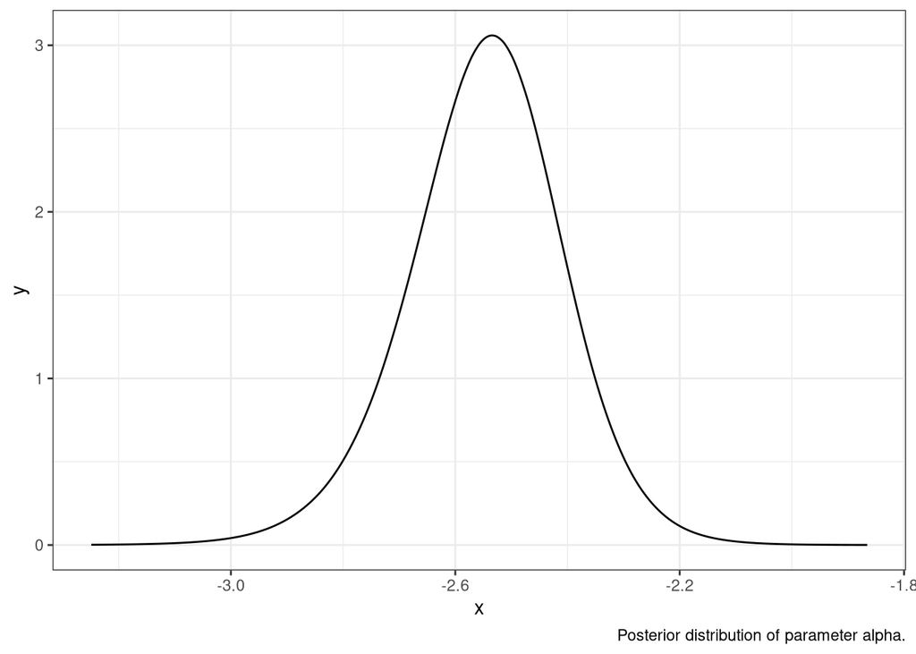

```r
library(ggplot2)

alpha <- res$marginals.fixed[[1]]

ggplot(data.frame(inla.smarginal(alpha)), aes(x, y)) +
  geom_line() +
  theme_bw() +
  labs(caption = "Posterior distribution of parameter alpha.")
```

Showing the quantile 0.05 of $\alpha$:

```r
quant <- inla.qmarginal(0.05, alpha)
quant
```

```
## [1] -2.78483
```

```r
inla.pmarginal(quant, alpha)
```

```
## [1] 0.05
```

Plotting the probability of $\alpha$ being lower than the 0.05 quantile:

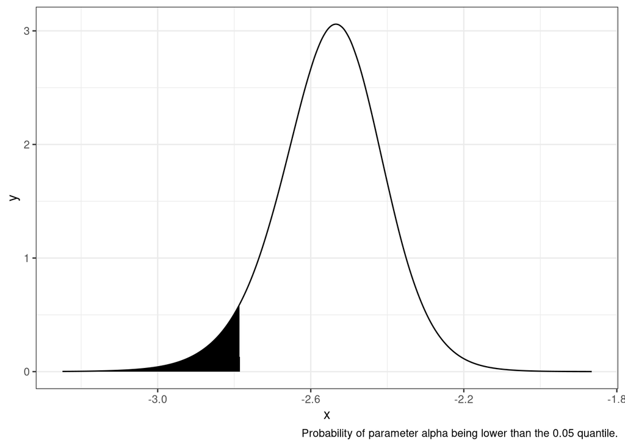

```r
ggplot(data.frame(inla.smarginal(alpha)), aes(x, y)) +
  geom_line() +
  geom_area(data = subset(data.frame(inla.smarginal(alpha)), x < quant), fill = "black") +
  theme_bw() +
  labs(caption = "Probability of parameter alpha being lower than the 0.05 quantile.")
```

Computing the prob density at particular values (say -2.5):

```r
inla.dmarginal(-2.5, alpha)
```

```
## [1] 2.940717
```

Plotting:

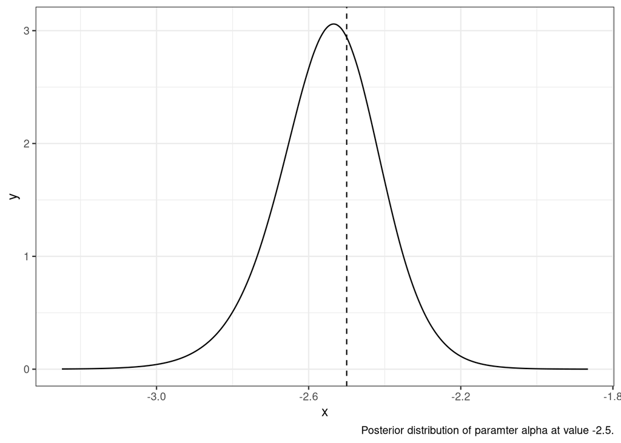

```r
ggplot(data.frame(inla.smarginal(alpha)), aes(x, y)) +
  geom_line() +
  geom_vline(xintercept = -2.5, linetype = "dashed") +
  theme_bw() +
  labs(caption = "Posterior distribution of paramter alpha at value -2.5.")
```

Computing a transformation of the marginal using `inla.tmarginal()` (to obtain the variance of the random effect $u_i$ by getting the marginal for the precision $\tau$ and then applying the inverse function):

```r
marg.variance <- inla.tmarginal(function(x) 1/x, res$marginals.hyperpar$"Precision for hospital")

head(marg.variance)
```

```
##                x         y
## [1,] 0.009340450 0.7701056
## [2,] 0.009947198 0.8437756
## [3,] 0.010506063 0.9098400
## [4,] 0.011027129 0.9704941
## [5,] 0.011518209 1.0246427
## [6,] 0.011985240 1.0733767
```

Plotting the posterior of the variance of the random effect, $u_i$:

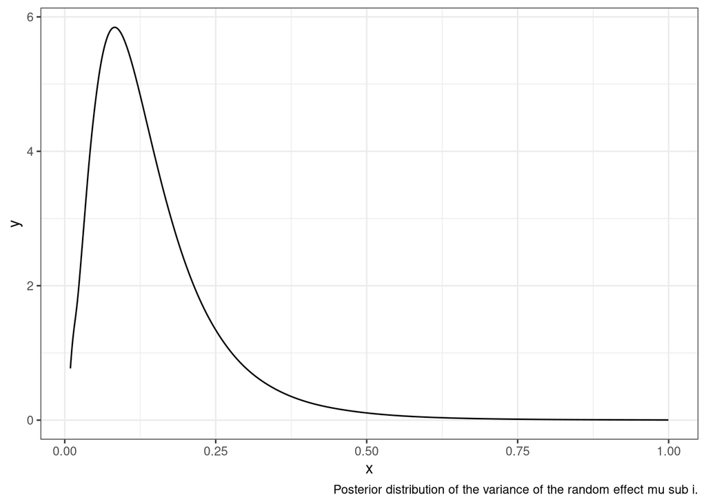

```r
ggplot(data.frame(inla.smarginal(marg.variance)), aes(x, y)) +
  geom_line() +
  theme_bw() +
  labs(caption = "Posterior distribution of the variance of the random effect mu sub i.")
```

Getting the mean posterior of the variance using `inla.emarginal()`:

```r
m <- inla.emarginal(function(x) x, marg.variance)
m
```

```
## [1] 0.1467058
```

Calculating the standard deviation using the expression $Var[X] = E[X^2] - E[X]^2$:

```r
mm <- inla.emarginal(function(x) x^2, marg.variance)

sqrt(mm - m^2)
```

```
## [1] 0.104374
```

Calculating the quantiles of the marginal variance using the `inla.qmarginal()` function:

```r
inla.qmarginal(c(0.025, 0.5, 0.975), marg.variance)
```

```
## [1] 0.02549812 0.12071214 0.42093187
```

Obtaining the summary statistics of the marginal, using `inla.zmarginal()`:

```r
inla.zmarginal(marg.variance)
```

```
## Mean            0.146706
## Stdev           0.104374
## Quantile  0.025 0.0254981
## Quantile  0.25  0.0757233
## Quantile  0.5   0.120712
## Quantile  0.75  0.187155
## Quantile  0.975 0.420932
```

Assessing the performance of the hospitals by examining the mortality rates can be done as follows: construct a data frame called `marginals` from the list `res$marginals.fitted.values`, add the `hospital` column to that, and plot the results:

```r
list_marginals <- res$marginals.fitted.values

marginals <- data.frame(do.call(rbind, list_marginals))
marginals$hospital <- rep(names(list_marginals), times = sapply(list_marginals, nrow))

head(marginals)
```

```
##             x          y            hospital
## 1 0.007992456 0.08659291 fitted.Predictor.01
## 2 0.008795514 0.14128707 fitted.Predictor.01
## 3 0.011816526 0.49799577 fitted.Predictor.01
## 4 0.018495907 2.49980805 fitted.Predictor.01
## 5 0.022721762 4.71493416 fitted.Predictor.01
## 6 0.026857263 7.45621177 fitted.Predictor.01
```

Plotting `marginals` using `facet_wrap()`:

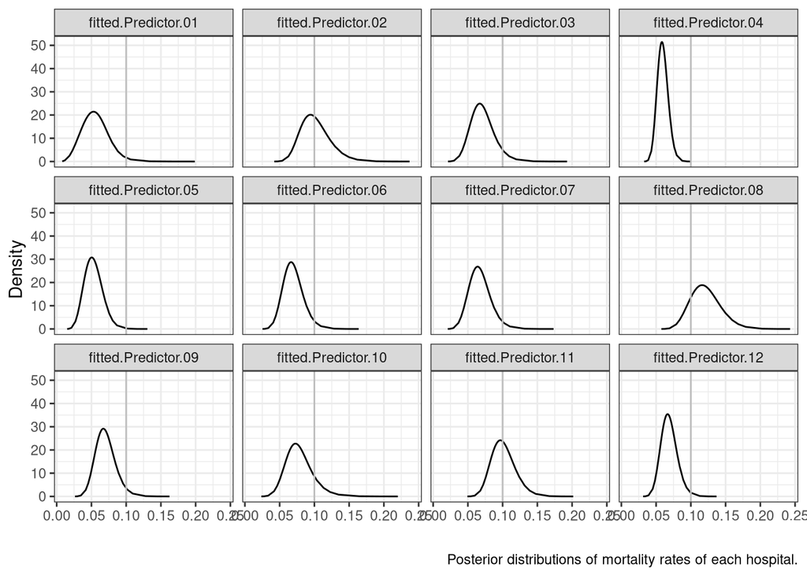

```r
marginals |> ggplot(
  aes(x = x, y = y)
) +
  geom_line() +
  facet_wrap(~ hospital) +
  labs(x = "", y = "Density") +
  geom_vline(xintercept = 0.1, col = "gray") +
  theme_bw() +
  labs(caption = "Posterior distributions of mortality rates of each hospital.")
```

Computing the probabilities that the mortality rates are greater than a given threshold, say 0.1:

```r
marg <- res$marginals.fitted.values[[1]]
1 - inla.pmarginal(q = 0.1, marginal = marg)
```

```
## [1] 0.01735564
```

Applying the above computation for all hospitals by using the `sapply()` function:

```r
sapply(res$marginals.fitted.values, FUN = function(marg){1 - inla.pmarginal(q = 0.1, marginal = marg)})
```

```
## fitted.Predictor.01 fitted.Predictor.02 fitted.Predictor.03 fitted.Predictor.04
##        1.735564e-02        4.847031e-01        5.727302e-02        4.740837e-06
## fitted.Predictor.05 fitted.Predictor.06 fitted.Predictor.07 fitted.Predictor.08
##        1.228063e-03        2.954124e-02        2.968435e-02        8.380117e-01
## fitted.Predictor.09 fitted.Predictor.10 fitted.Predictor.11 fitted.Predictor.12
##        3.045711e-02        1.270382e-01        4.920255e-01        9.184839e-03
```